# Exploring the BRFSS data

## Setup

### Load packages

```r
library(ggplot2)
library(dplyr)
```

Adding a few useful packages

```r
library(ggthemes)
library(scales)
```

### Load data

```r
load("brfss2013.RData")
attach(brfss2013)
```

## Part 1: Data

The Behavioral Risk Factor Surveillance System (BRFSS) is a telephone survey that collects data about U.S. residents regarding their health-related risk behaviors, chronic health conditions, and use of preventive services. It collects data in all 50 states as well as the District of Columbia and three U.S. territories. BRFSS completes more than 400,000 adult interviews each year, making it the largest continuously conducted health survey system in the world.

**Population:** Health characteristics estimated from the BRFSS pertain to the non-institutionalized adult population, aged 18 years or older, who reside in the US.

Respondent data are forwarded to CDC to be aggregated for each state, returned with standard tabulations, and published at year’s end by each state. Source: https://www.cdc.gov/brfss/

**Random sampling?**

“The survey is conducted using Random Digit Dialing (RDD) techniques on both landlines and cell phones.” Source: https://www.cdc.gov/brfss/about/brfss_faq.htm Sampling appears to be random, therefore, results can be generalized to the population of the US.

*Bias:*

1.Selection bias:

There might be some selection bias introduced due to the survey being telephone-based. A proportion of the population of interest might not own telephones; landlines or cellular.

2.Response bias:

Also, response bias may arise from some people not answering their phones.

3.Recall bias:

Participants are asked questions to which they might not remember the answers.

**Random assignment?**

Since this is a cross-sectional study, it is observational, not interventional, So random assignment is not possible. Therefore, we cannot establish causality, only associations.

## Part 2: Research questions

**Research quesion 1:**

Is there an association between the duration of sleep and alcohol consumption? Given that sleep disorders are common in patients suffering from depression, does this relationship differ in those that have been diagnosed with a depressive disorder than those that haven’t?

Source: https://www.sleepfoundation.org/articles/depression-and-sleep

**Research quesion 2:**

Doctors constantly say that high cholesterol is bad for you and is a risk factor for heart disease. Does this data confirm that? Does the percentage of heart attack diagnosis increase with high cholesterol? And, since obesity is considered a risk factor for both high cholesterol and heart disease, is body mass index a confounder that affects the relationship between the two?

Sources: https://www.mayoclinic.org/diseases-conditions/high-blood-cholesterol/symptoms-causes/syc-20350800 https://my.clevelandclinic.org/health/articles/17308-obesity--heart-disease

**Research quesion 3:**

Does satisfaction with life increase with income? Since I’m currently broke, I’d like to know.

## Part 3: Exploratory data analysis

# Research quesion 1:

Difference between those with and without depressive disorder in mean sleeping duration and average alcohol drinking per day in the last 30 days.

**Variables of Interest**

1.*addepev2:* Ever Told You Had A Depressive Disorder

2.*sleptim1:* How Much Time Do You Sleep

3.*avedrnk2:* Avg Alcoholic Drinks Per Day In Past 30

First, getting to know the variables

```r
class(addepev2)
```

```
## [1] "factor"
```

```r
class(avedrnk2)
```

```
## [1] "integer"
```

```r
class(sleptim1)
```

```
## [1] "integer"
```

Then, taking a quick look at the some of the observations

```r
levels(addepev2)
```

```
## [1] "Yes" "No"
```

```r
head(avedrnk2)
```

```
## [1]  2 NA  4  2  2 NA
```

```r
head(sleptim1)
```

```
## [1] NA  6  9  8  6  8
```

Dealing with missing data by filtering NAs and rewriting our dataframe with the new “clean” one.

```r
brfss2013 <- brfss2013 %>%
 filter(!is.na(addepev2), !is.na(sleptim1), !is.na(avedrnk2))
```

**Visualizing the distribution of our variables**

**First,** the grouping variable:the percentage of people with depressive disorders

Geom_bar will be used to create a bar plot since it is a categorical variable.

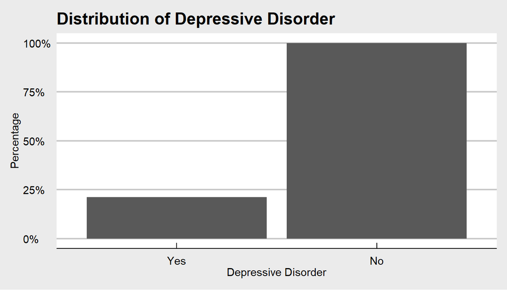

```r
ggplot(data = brfss2013, aes(x = addepev2,y = stat(count/ max(count)))) +
  geom_bar(na.rm = T) +
  scale_y_continuous(labels = percent_format()) +
  labs(x = "Depressive Disorder", y = "Percentage",
       title = "Distribution of Depressive Disorder") +
  theme_economist_white()
```

**Second,** The distribution of Sleeping Duration

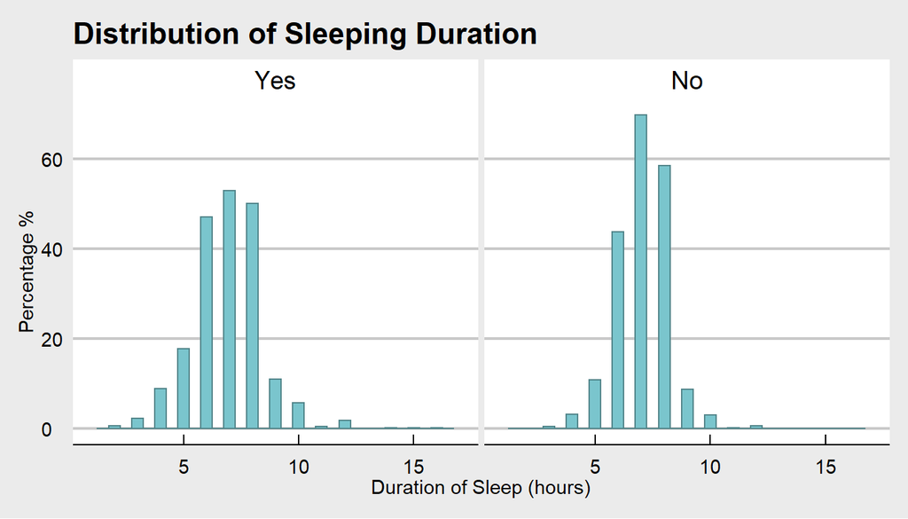

```r
ggplot(data = brfss2013, aes(x = sleptim1, y = ..density..*100)) +
  geom_histogram(color = "cadetblue4", fill = "cadetblue3", na.rm = T,binwidth = 0.5) +
  xlim(1,17) +
  labs(x = "Duration of Sleep (hours)", y = "Percentage %",
       title = "Distribution of Sleeping Duration") +
  facet_wrap(~ addepev2) +
  theme_economist_white()
```

The distribution appears to be nearly symmetrical in both groups, with a mean around 7 hours of sleep and very few outliers(a very small proportion of the population in both groups sleeps for more than 15 hours a day).

**Third,** The distribution of Average Alcohol Drinks

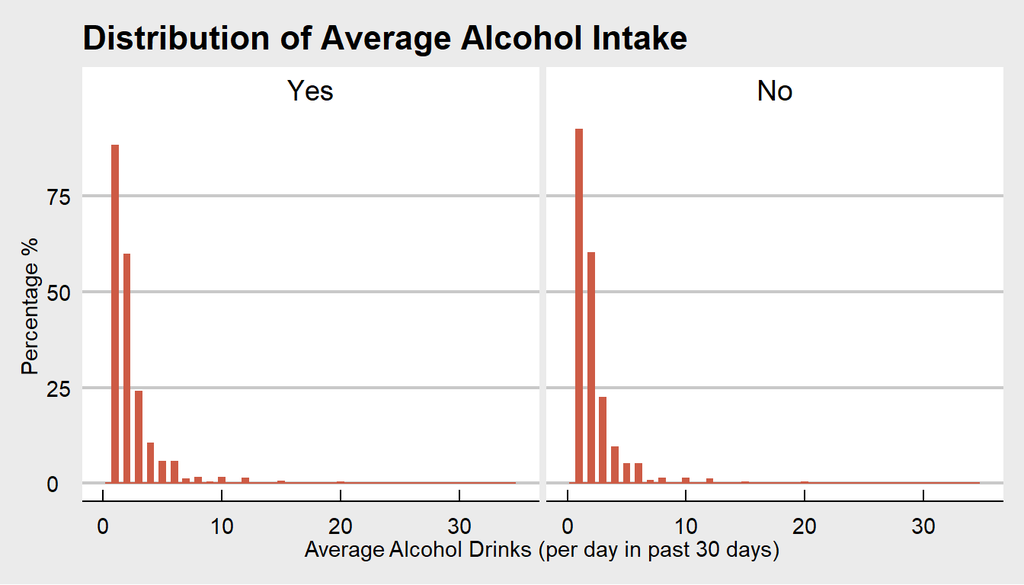

```r
ggplot(data = brfss2013, aes(x = avedrnk2, y = ..density..*100)) +
  geom_histogram(color = "coral3", fill = "coral3", na.rm = T, binwidth = 0.5) +
  xlim(0,35) +
  labs(x = "Average Alcohol Drinks (per day in past 30 days)", y = "Percentage %",
       title = "Distribution of Average Alcohol Intake") +
  facet_grid(~ addepev2) +
  theme_economist_white()
```

Unlike sleeping duration, the distribution of alcohol intake is heavily right skewed with a very notable outlier of 30 drinks per day.

**Performing a quick numerical summary**

Since the distribution of sleeping duration is symmetrical, we will use mean and standard deviation(SD) to summarize it. But median and Interquantile range(IQR) will be used to summarize the right-skewed distribution of average alcohol drinks.

```r
brfss2013 %>%
  group_by(addepev2) %>%
    summarise(count = n(), mean_sleep = mean(sleptim1),
                           SD_sleep = sd(sleptim1),
                           median_drink = median(avedrnk2),
                           IQR_drink = IQR(avedrnk2))
```

```
## # A tibble: 2 x 6
##   addepev2  count mean_sleep SD_sleep median_drink IQR_drink
##   <fct>     <int>      <dbl>    <dbl>        <int>     <dbl>
## 1 Yes       40179       6.92     1.60            2         2
## 2 No       188739       7.06     1.20            2         1
```

**Visualing the relationship between the two variables**

First, the relationship between Sleep Duration and Alcohol consumption

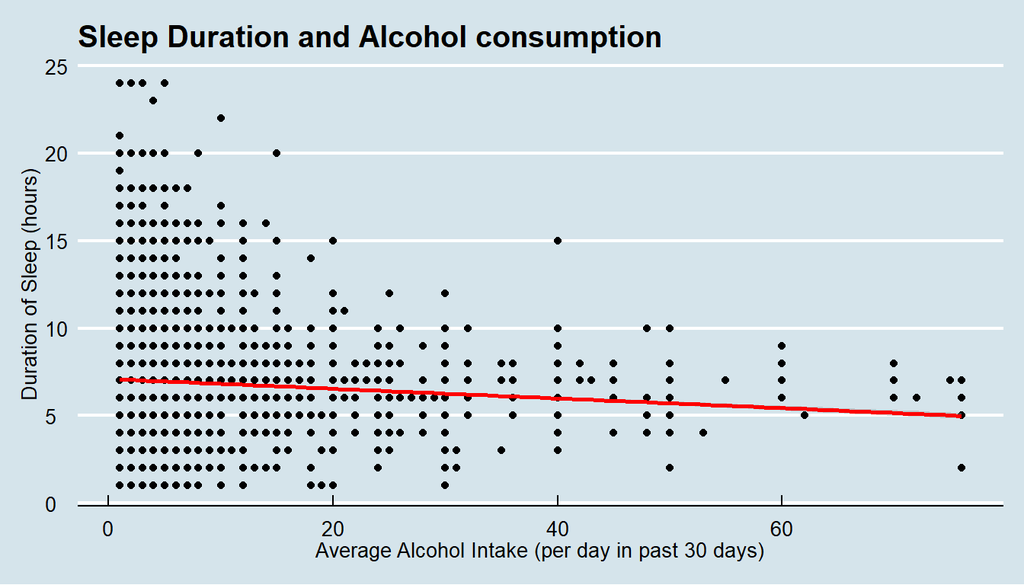

```r
ggplot(data = brfss2013, aes(x = avedrnk2, y = sleptim1)) +
  geom_point() +
  geom_smooth(method = "lm", colour = "red") +
  labs(x = "Average Alcohol Intake (per day in past 30 days)", y = "Duration of Sleep (hours)",
  title = "Sleep Duration and Alcohol consumption") +
  theme_economist()
```

But, grouped by the presence of a depressive disorder

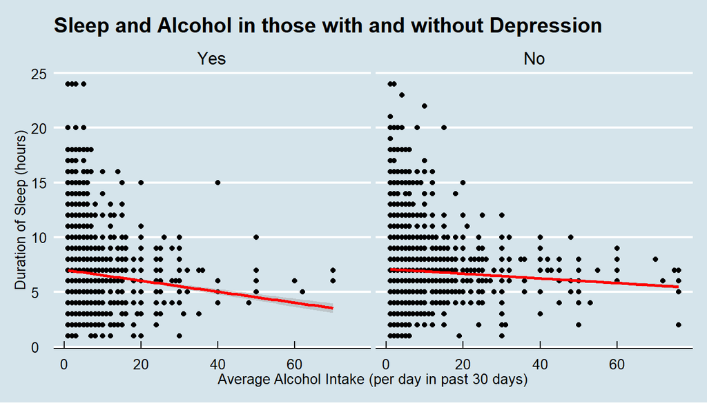

```r
ggplot(data = brfss2013, aes(x = avedrnk2, y = sleptim1)) +
  geom_point(na.rm = TRUE) +
  geom_smooth(method = "lm", colour = "red") +
  labs(x = "Average Alcohol Intake (per day in past 30 days)", y = "Duration of Sleep (hours)",
  title = "Sleep and Alcohol in those with and without Depression") +
  facet_grid(~ addepev2) +
  theme_economist()
```

There appears to be an inverse association- albeit a small one- between sleep duration and alcohol intake. Large amounts of alcohol appear to slightly decrease sleep duaration,more so in those with depressive disorders. This association needs to be properly studied with regression models.

# Research quesion 2:

The relationship between high cholesterol and heart attacks among various categories of body mass index.

**Variables of Interest**

1.*X_bmi5cat:* Computed Body Mass Index Categories

2.*cvdinfr4:* Ever Diagnosed With Heart Attack

3.*toldhi2:* Ever Told Blood Cholesterol High

First, getting to know the variables

```r
class(X_bmi5cat)
```

```
## [1] "factor"
```

```r
class(cvdinfr4)
```

```
## [1] "factor"
```

```r
class(toldhi2)
```

```
## [1] "factor"
```

Then, taking a quick look at some of the observations

```r
levels(X_bmi5cat)
```

```
## [1] "Underweight"   "Normal weight" "Overweight"    "Obese"
```

```r
levels(cvdinfr4)
```

```
## [1] "Yes" "No"
```

```r
levels(toldhi2)
```

```
## [1] "Yes" "No"
```

Dealing with missing data by filtering NAs and rewriting our dataframe with the new “clean” one.

```r
brfss2013 <- brfss2013 %>%
 filter(!is.na(X_bmi5cat), !is.na(cvdinfr4), !is.na(toldhi2))
```

**Summarizing and visualizing the distribution of our variables**

Geom_bar will be used to create bar plots since they are categorical variables.

**First,** body mass index

```r
table(X_bmi5cat)
```

```
## X_bmi5cat
##   Underweight Normal weight    Overweight         Obese
##          8267        154898        167084        134799
```

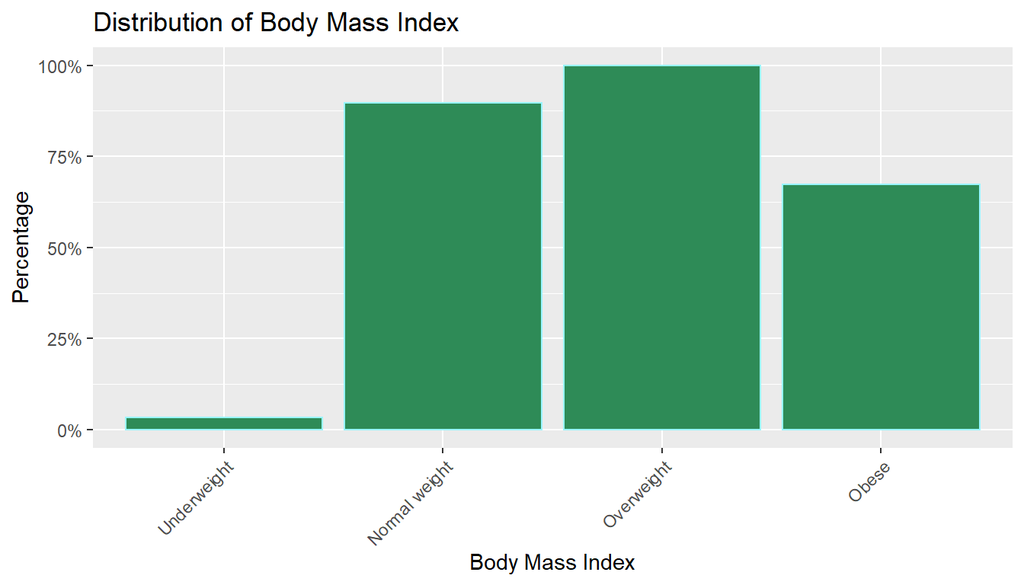

```r
ggplot(data = brfss2013, aes(x = X_bmi5cat,y = stat(count/ max(count)))) +
  geom_bar(color = "cadetblue1", fill = "seagreen4") +
  scale_y_continuous(labels = percent_format()) +
  labs(x = "Body Mass Index", y = "Percentage") +
  ggtitle("Distribution of Body Mass Index") +
  theme(axis.text.x = element_text(angle = 45, hjust = 1))
```

The plot shows that the majority of the population is either overweight or obese, as confirmed by the summary.

**Second,** diagnosis of heart attack

```r
table(cvdinfr4)
```

```
## cvdinfr4
##    Yes     No
##  29284 459904
```

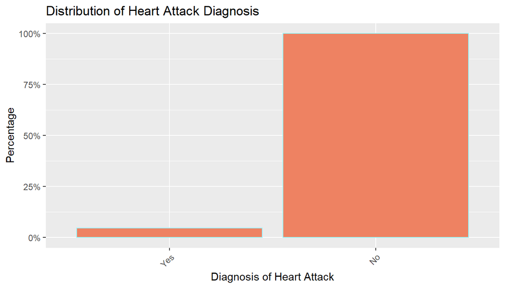

```r
ggplot(data = brfss2013, aes(x = cvdinfr4,y = stat(count/ max(count)))) +
  geom_bar(color = "cadetblue1", fill = "salmon2") +
  scale_y_continuous(labels = percent_format()) +
  labs(x = "Diagnosis of Heart Attack", y = "Percentage") +
  ggtitle("Distribution of Heart Attack Diagnosis") +
  theme(axis.text.x = element_text(angle = 45, hjust = 1))
```

The majority of the population were not diagnosed with heart attacks.

**Third,** diagnosis of high cholesterol

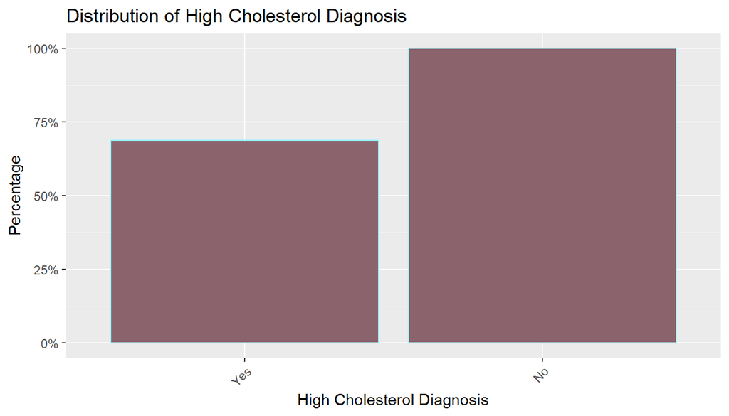

```r
ggplot(data = brfss2013, aes(x = toldhi2,y = stat(count/ max(count)))) +
  geom_bar(color = "cadetblue1", fill = "pink4") +
  scale_y_continuous(labels = percent_format()) +
  labs(x = "High Cholesterol Diagnosis", y = "Percentage") +
  ggtitle("Distribution of High Cholesterol Diagnosis") +
  theme(axis.text.x = element_text(angle = 45, hjust = 1))
```

The percentage of high cholesterol seems to be relatively very high, which is expected, given the high percentage of obesity in our sample.

**Summarizing and visualizing the relationship between high cholesterol and heart attack diagnosis**

```r
table(cvdinfr4, toldhi2)
```

```
##         toldhi2
## cvdinfr4    Yes     No
##      Yes  19560   8299
##      No  162778 227472
```

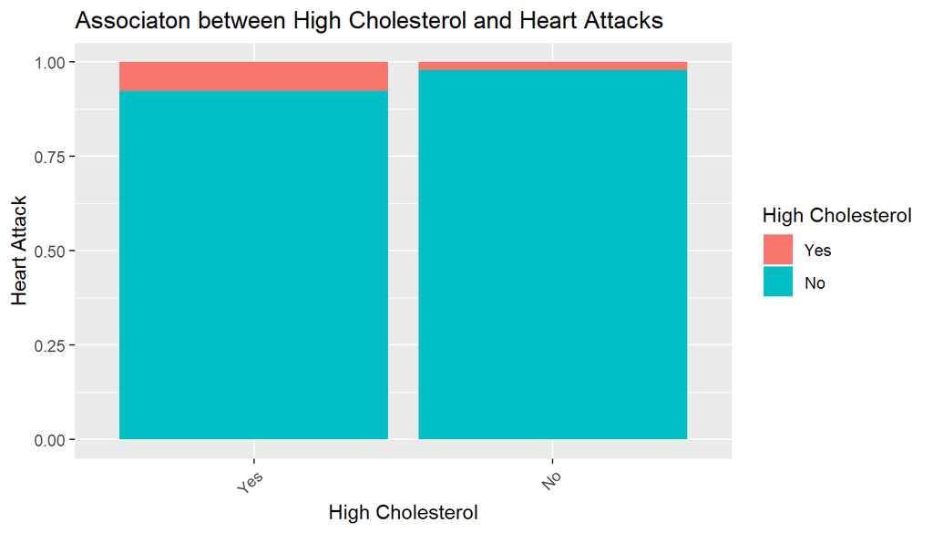

```r
ggplot(brfss2013, aes(x = toldhi2, fill = cvdinfr4)) +
  geom_bar(position = "fill",) +
  labs(x = "High Cholesterol", y = "Heart Attack") +
  ggtitle("Associaton between High Cholesterol and Heart Attacks") +
  scale_fill_discrete(name = "High Cholesterol") +
  theme(axis.text.x = element_text(angle = 45, hjust = 1))
```

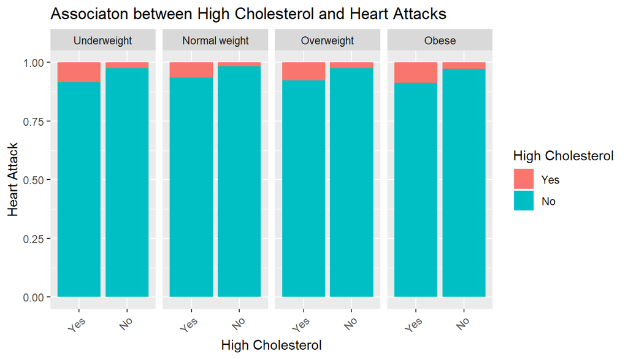

```r
ggplot(brfss2013, aes(x = toldhi2, fill = cvdinfr4)) +
  geom_bar(position = "fill",) +
  labs(x = "High Cholesterol", y = "Heart Attack") +
  ggtitle("Associaton between High Cholesterol and Heart Attacks") +
  scale_fill_discrete(name = "High Cholesterol") +
  facet_grid(~ X_bmi5cat) +
  theme(axis.text.x = element_text(angle = 45, hjust = 1))
```

The plots and the summary show a positive association between high cholesterol and the percentage of heart attack diagnosis. More people that have high cholesterol have also been diagnosed with heart attacks than those with low cholesterol. The association between the two variables does not seem to change with various categories of body mass index. But it is yet to be confirmed and quantified with statistical tests and models.

**Research quesion 3:**

The relationship between income and satisfation with life

**Variables of Interest**

1.*income2:* Income Level

2.*lsatisfy:* Satisfaction With Life

First, getting to know the variables

```r
class(income2)
```

```
## [1] "factor"
```

```r
class(lsatisfy)
```

```
## [1] "factor"
```

Then, taking a quick look at some of the observations

```r
levels(income2)
```

```
## [1] "Less than $10,000" "Less than $15,000" "Less than $20,000"
## [4] "Less than $25,000" "Less than $35,000" "Less than $50,000"
## [7] "Less than $75,000" "$75,000 or more"
```

```r
levels(lsatisfy)
```

```
## [1] "Very satisfied"    "Satisfied"         "Dissatisfied"
## [4] "Very dissatisfied"
```

Dealing with missing data by filtering NAs and rewriting our dataframe with the new “clean” one.

```r
brfss2013 <- brfss2013 %>%
  filter(!is.na(income2), !is.na(lsatisfy))
```

**Visualizing the distribution of our variables**

Geom_bar will be used to create bar plots since they are categorical variables.

**First,** income level

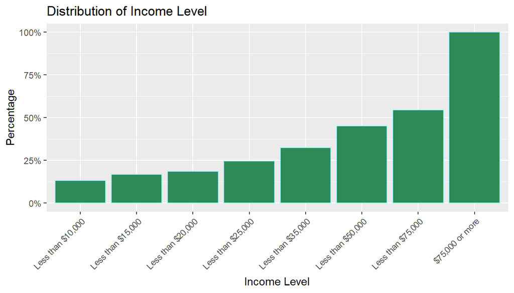

```r
ggplot(data = brfss2013, aes(x = income2,y = stat(count/ max(count)))) +
  geom_bar(color = "cadetblue1", fill = "seagreen4") +
  scale_y_continuous(labels = percent_format()) +
  labs(x = "Income Level", y = "Percentage") +
  ggtitle("Distribution of Income Level") +
  theme(axis.text.x = element_text(angle = 45, hjust = 1))
```

**Second,** Satisfaction with life

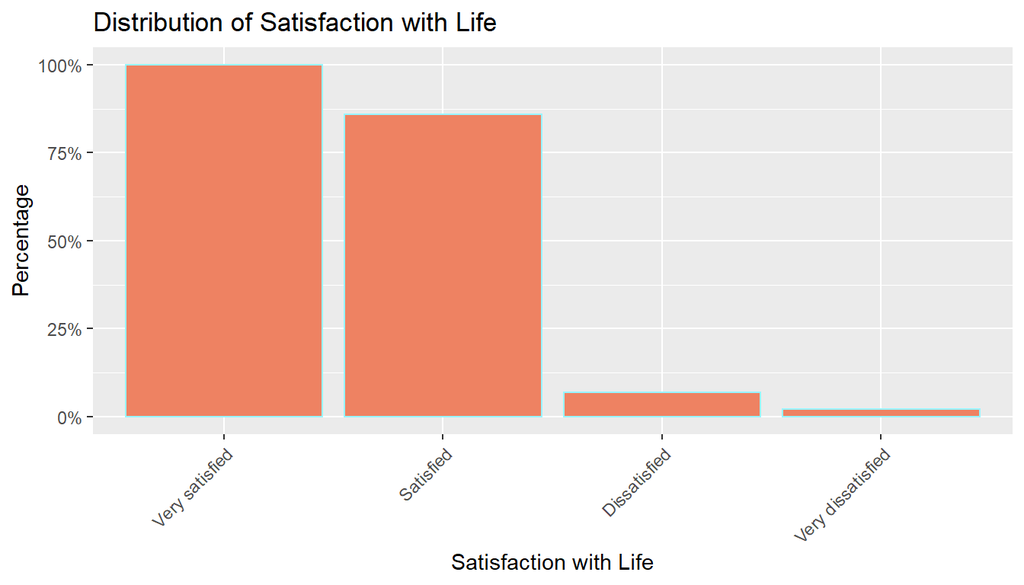

```r
ggplot(data = brfss2013, aes(x = lsatisfy, y = stat(count/ max(count)))) +
  geom_bar(color = "cadetblue1", fill = "salmon2") +
  scale_y_continuous(labels = percent_format()) +
  labs(x = "Satisfaction with Life", y = "Percentage") +
  ggtitle("Distribution of Satisfaction with Life") +
  theme(axis.text.x = element_text(angle = 45, hjust = 1))
```

The plot shows that the majority of the population are satisfied or very satisfied with life, with less than 15% dissatisfied or very dissatisfied.

**Performing a quick numerical summary**

```r
table(income2, lsatisfy)
```

```
##                    lsatisfy
## income2             Very satisfied Satisfied Dissatisfied
##   Less than $10,000            238       461          113
##   Less than $15,000            309       548          101
##   Less than $20,000            374       594           52
##   Less than $25,000            398       572           58
##   Less than $35,000            517       587           67
##   Less than $50,000            634       589           43
##   Less than $75,000            708       504           28
##   $75,000 or more             1112       563           28
##                    lsatisfy
## income2             Very dissatisfied
##   Less than $10,000                52
##   Less than $15,000                27
##   Less than $20,000                19
##   Less than $25,000                16
##   Less than $35,000                 8
##   Less than $50,000                 8
##   Less than $75,000                 1
##   $75,000 or more                   3
```

**Visualizing the relationship between the two variables**

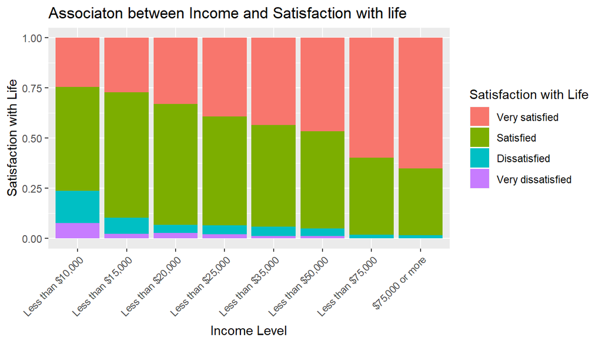

```r
ggplot(brfss2013, aes(x = income2, fill = lsatisfy)) +
  geom_bar(position = "fill",) +
  labs(x = "Income Level", y = "Satisfaction with Life") +
  ggtitle("Associaton between Income and Satisfaction with life") +
  scale_fill_discrete(name = "Satisfaction with Life") +
  theme(axis.text.x = element_text(angle = 45, hjust = 1))
```

Both the table and the plot appear to show that there is a positive relationship between the level of income and satisfation with life. Those with higher income tend to be more satisfied with their lives. This finding needs to be confirmed and quantified with regression models and statistical tests.